# HW_10

Cody Grainger

26 July 2020

### Hw_10: Data Visualization 2

##Import and wrangle

Loading initial Libraries

```r
library(here)
library(tidyverse)
library(GGally)
library(patchwork)
```

Importing the ‘sparrows.txt’ data and assigning it to a variable

```r
sparrows_raw <- read_tsv(here("data","sparrows.txt"))
sparrows_raw
```

| wingcrd | flatwing | tarsus | head | culmen | nalospi | wt | bandstat | initials | Year | Month | Day | Location | SpeciesCode | Sex | Age |
| --- | --- | --- | --- | --- | --- | --- | --- | --- | --- | --- | --- | --- | --- | --- | --- |
| 59.0 | 60.0 | 22.3 | 31.2 | 12.3 | 13.0 | 9.5 | 1 | 2 | 2002 | 9 | 19 | 4 | 1 | 0 | 2 |
| 54.0 | 55.0 | 20.3 | 28.3 | 10.8 | 7.8 | 12.2 | 1 | 2 | 2002 | 10 | 4 | 4 | 3 | 0 | 2 |
| 53.0 | 54.0 | 21.6 | 30.2 | 12.5 | 8.5 | 13.8 | 1 | 2 | 2002 | 10 | 4 | 4 | 3 | 0 | 2 |
| 55.0 | 56.0 | 19.7 | 30.4 | 12.1 | 8.3 | 13.8 | 1 | 8 | 2002 | 7 | 30 | 9 | 1 | 0 | 2 |
| 55.0 | 56.0 | 20.3 | 28.7 | 11.2 | 8.0 | 14.1 | 1 | 3 | 2002 | 10 | 4 | 4 | 3 | 0 | 2 |
| 53.5 | 54.5 | 20.8 | 30.6 | 12.8 | 8.6 | 14.8 | 1 | 7 | 2004 | 8 | 2 | 1 | 1 | 0 | 2 |
| 55.5 | 57.0 | 20.3 | 29.5 | 11.5 | 8.5 | 15.0 | 1 | 3 | 2002 | 10 | 4 | 4 | 3 | 0 | 2 |
| 55.0 | 56.0 | 20.9 | 30.0 | 11.7 | 8.5 | 15.0 | 1 | 3 | 2002 | 10 | 2 | 5 | 3 | 0 | 1 |
| 54.0 | 56.0 | 21.4 | 29.8 | 11.0 | 8.7 | 15.1 | 1 | 1 | 2002 | 10 | 21 | 7 | 3 | 0 | 2 |
| 55.0 | 56.0 | 20.4 | 29.8 | 11.2 | 8.1 | 15.1 | 1 | 2 | 2002 | 10 | 2 | 5 | 3 | 0 | 2 |

[output cut: 990 more lines]

Creating two new columns for the sparrows_raw data and creating a new tibble. setting the row order will create a variable to label the rows 1:1265 and the “.” references the original dataframe for reference in the pipe

```r
sparrows <- sparrows_raw %>%
  mutate(box_group="sparrows",
         row_order=1:nrow(.))

view(sparrows)
```

The rest of the notebook will reference Zuur et al.

## Figure 2: Outliars

A boxplot for the sparrows data to observe possible outliars

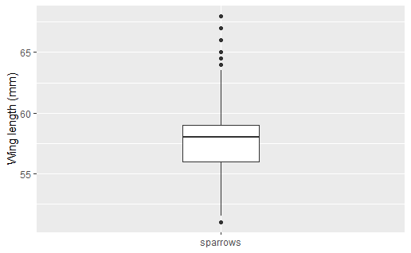

```r
plot_box <- sparrows %>%
  ggplot(aes(x=box_group,
             y=wingcrd))+
  geom_boxplot(width=0.25)+
  labs(x=NULL,
       y="Wing length (mm)")

plot_box
```

For better assessment of the full range of values a cleveland plot can be used

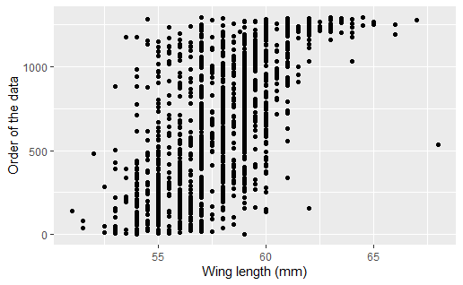

```r
plot_cleveland <- sparrows %>%
  ggplot(aes(x= wingcrd,y=row_order))+
  geom_point()+
  labs(x="Wing length (mm)",
       y="Order of the data")

plot_cleveland
```

using the patchwork package to put the plots together side by side

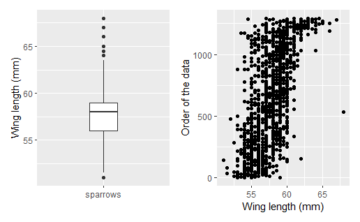

```r
plot_box+plot_cleveland
```

Flipping the cleveland plot for better comparison with the boxplot

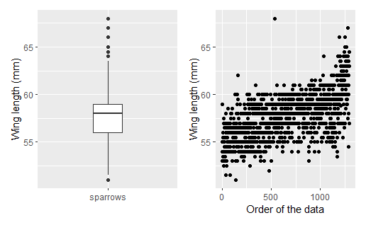

```r
plot_box+plot_cleveland+coord_flip()
```

## Figure 3: Outliars

Creating 6 scatter plots and combining them with the patchwork package. ncol set to 3

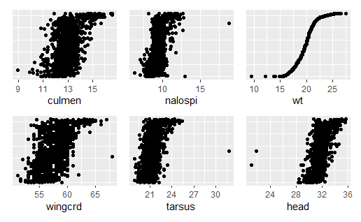

```r
#culmen
p_culmen <- sparrows %>%
  ggplot(aes(y=row_order))+
  geom_point(aes(x=culmen))+
  theme(axis.title.y=element_blank(),
        axis.text.y=element_blank(),
        axis.ticks.y=element_blank())

#nalopsi
p_nalospi <- sparrows %>%
  ggplot(aes(y=row_order))+
  geom_point(aes(x=nalospi))+
  theme(axis.title.y=element_blank(),
        axis.text.y=element_blank(),
        axis.ticks.y=element_blank())

#wt
p_wt <- sparrows %>%
  ggplot(aes(y=row_order))+
  geom_point(aes(x=wt))+
  theme(axis.title.y=element_blank(),
        axis.text.y=element_blank(),
        axis.ticks.y=element_blank())

#wingcrd
p_wingcrd <- sparrows %>%
  ggplot(aes(y=row_order))+
  geom_point(aes(x=wingcrd))+
  theme(axis.title.y=element_blank(),
        axis.text.y=element_blank(),
        axis.ticks.y=element_blank())

#tarsus
p_tarsus <- sparrows %>%
  ggplot(aes(y=row_order))+
  geom_point(aes(x=tarsus))+
  theme(axis.title.y=element_blank(),
        axis.text.y=element_blank(),
        axis.ticks.y=element_blank())

#head
p_head <- sparrows %>%
  ggplot(aes(y=row_order))+
  geom_point(aes(x=head))+
  theme(axis.title.y=element_blank(),
        axis.text.y=element_blank(),
        axis.ticks.y=element_blank())


plot2 <- p_culmen+p_nalospi+p_wt+p_wingcrd+p_tarsus+p_head+plot_layout(ncol=3)

plot2
```

## Figure 5: distribution

assigning individuals to a bin. bin width set to 0.5 for the sparrows data. then using facet_wrap to alphabetically arrange the plots by month for plot 2. Additionally a density plot is created and colored according to months jun, july,august

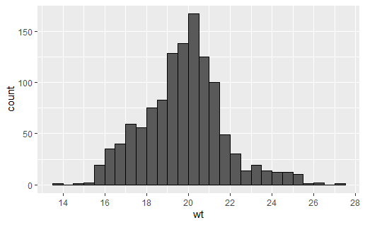

```r
#Histogram
h1 <- sparrows %>%
  filter(Month %in% 6:8) %>%
  ggplot()+
  geom_histogram(aes(x=wt),
                 binwidth=0.5,
                 boundary=0,
                 closed="right",
                 color="black")+
  scale_x_continuous(breaks=seq(14,28,by=2))
h1
```

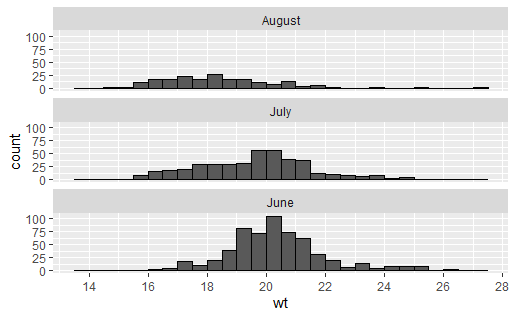

```r
#Histogram2: Faceted Histogram
h2 <- sparrows %>%
  filter(Month %in% 6:8) %>%
  mutate(Month=case_when(
    Month==6~"June",
    Month==7~"July",
    Month==8~"August")) %>%
  ggplot()+
  geom_histogram(aes(x=wt),
                 binwidth=0.5,
                 boundary=0,
                 color="black")+
  scale_x_continuous(breaks=seq(14,28,by=2))+
  facet_wrap(~Month,ncol=1)
h2
```

```r
#Unsolved wip
h3 <- sparrows %>%
  filter(Month %in% 6:8) %>%
  mutate(Month=case_when(
    Month==6~"June",
    Month==7~"July",
    Month==8~"August")) %>%
  ggplot()+
  geom_density(aes(x=wt,fill=Month,alpha=0.30),
                 binwidth=0.5,
                 boundary=0,
                 color="black")+
  scale_x_continuous(breaks=seq(14,28,by=2))
```

```
Ignoring unknown parameters: binwidth, boundary
```

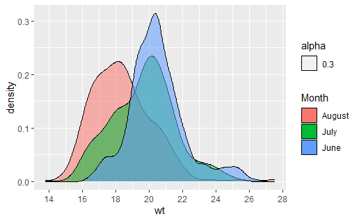

```r
h3
```

Adding the 2 plots together

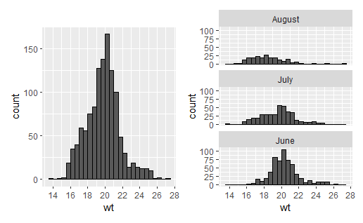

```r
h1+h2
```

using ggscatmat many scatter plots can be created quickly

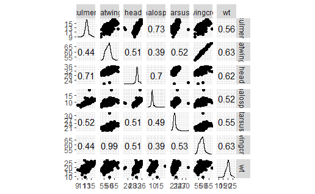

```r
sparrows %>% ggscatmat(columns=1:7)
```

## Figure 11: interactions

The code below shows the interaction between sex and season. only months 5-9 are used and immature individuals are removed.mutate assigns names to the months according to the months number in the data set.a trend line is added with the se shader removed.

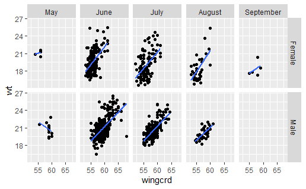

```r
month_order=c("May","June","July","August","September")
sparrows %>%
  filter(Month %in% 5:9,
         Sex !=0) %>%
  mutate(Month=case_when(
    Month==5 ~ "May",
    Month==6 ~ "June",
    Month==7 ~ "July",
    Month==8 ~ "August",
    Month==9 ~ "September"),
    Month=factor(Month,levels=month_order,ordered=TRUE),
    Sex=ifelse(Sex==4,"Male","Female")) %>%
  ggplot(aes(x=wingcrd,
             y=wt))+
  geom_point()+
  geom_smooth(method="lm",se=FALSE)+
  facet_grid(Sex~Month)
```